# Case Study: How Does a Bike-Share Navigate Speedy Success

Sukumar

18/07/2021

# Scenario

You are a junior data analyst working in the marketing analyst team at Cyclistic, a bike-share company in Chicago. The director of marketing believes the company’s future success depends on maximizing the number of annual memberships. Therefore, your team wants to understand how casual riders and annual members use Cyclistic bikes differently. From these insights, your team will design a new marketing strategy to convert casual riders into annual members. But first, Cyclistic executives must approve your recommendations, so they must be backed up with compelling data insights and professional data visualizations.

# About the company

In 2016, Cyclistic launched a successful bike-share offering. Since then, the program has grown to a fleet of 5,824 bicycles that are geotracked and locked into a network of 692 stations across Chicago. The bikes can be unlocked from one station and returned to any other station in the system anytime.

Until now, Cyclistic’s marketing strategy relied on building general awareness and appealing to broad consumer segments. One approach that helped make these things possible was the flexibility of its pricing plans: single-ride passes, full-day passes,and annual memberships. Customers who purchase single-ride or full-day passes are referred to as casual riders. Customers who purchase annual memberships are Cyclistic members.

Cyclistic’s finance analysts have concluded that annual members are much more profitable than casual riders. Although the pricing flexibility helps Cyclistic attract more customers, Moreno believes that maximizing the number of annual members will be key to future growth. Rather than creating a marketing campaign that targets all-new customers, Moreno believes there is a very good chance to convert casual riders into members. She notes that casual riders are already aware of the Cyclistic program and have chosen Cyclistic for their mobility needs.

Moreno has set a clear goal: Design marketing strategies aimed at converting casual riders into annual members. In order to do that, however, the marketing analyst team needs to better understand how annual members and casual riders differ, why casual riders would buy a membership, and how digital media could affect their marketing tactics. Moreno and her team are interested in analyzing the Cyclistic historical bike trip data to identify trends.

## Business Task

Understanding how annual members and casual riders use Cyclistic bikes differently.

## Processing data

The dataset I have used for this case study is [Divvy Trips](https://divvy-tripdata.s3.amazonaws.com/index.html). Note:The datasets have a different name because Cyclistic is a fictional company. For the purposes of this case study, the datasets are appropriate and will enable you to answer the business questions. The data has been made available by Motivate International Inc.

The tool that I used is R because the dataset is large and R can handle large datasets easily. Also, execl is used to remove duplicate values from the datasets before uploading them to R.

Now load the required libraries.

```r
library(tidyverse)
library(lubridate)
```

```r
library(ggplot2)
```

Next upload the data to R.

```r
q2_2019 <- read.csv("C:/Users/sukum/Desktop/Case Study 1/csv/Divvy_Trips_2019_Q2 - Copy.csv")
q3_2019 <- read.csv("C:/Users/sukum/Desktop/Case Study 1/csv/Divvy_Trips_2019_Q3 - Copy.csv")
q4_2019 <- read.csv("C:/Users/sukum/Desktop/Case Study 1/csv/Divvy_Trips_2019_Q4 - Copy.csv")
q1_2020 <- read.csv("C:/Users/sukum/Desktop/Case Study 1/csv/Divvy_Trips_2020_Q1 - Copy.csv")
```

### Wrangling the data and combining into a single file

```r
colnames(q2_2019)
```

```
##  [1] "Rental_ID"                    "Local_Start_Time"
##  [3] "Local_End_Time"               "Bike_ID"
##  [5] "Duration_In_Seconds_Uncapped" "Start_Station_ID"
##  [7] "Start_Station_Name"           "End_Station_ID"
##  [9] "End_Station_Name"             "User_Type"
## [11] "Member_Gender"                "Member_Birthday_Year"
## [13] "ride_length"                  "day_of_week"
```

```r
colnames(q3_2019)
```

```
##  [1] "trip_id"           "start_time"        "end_time"
##  [4] "bikeid"            "tripduration"      "from_station_id"
##  [7] "from_station_name" "to_station_id"     "to_station_name"
## [10] "usertype"          "gender"            "birthyear"
## [13] "ride_length"       "day_of_week"
```

```r
colnames(q4_2019)
```

```
##  [1] "trip_id"           "start_time"        "end_time"
##  [4] "bikeid"            "tripduration"      "from_station_id"
##  [7] "from_station_name" "to_station_id"     "to_station_name"
## [10] "usertype"          "gender"            "birthyear"
```

```r
colnames(q1_2020)
```

```
##  [1] "ride_id"            "rideable_type"      "started_at"
##  [4] "ended_at"           "start_station_name" "start_station_id"
##  [7] "end_station_name"   "end_station_id"     "start_lat"
## [10] "start_lng"          "end_lat"            "end_lng"
## [13] "member_casual"      "ride_length"        "day_of_week"
```

Some columns from q2_2019, q3_2019, and q4_2019 are renamed so that they are in consistent with the latest quarter q1_2020.

```r
q4_2019 <- rename(q4_2019, ride_id = trip_id,
                  rideable_type = bikeid,
                  started_at = start_time,
                  ended_at = end_time,
                  start_station_name = from_station_name,
                  start_station_id = from_station_id,
                  end_station_name = to_station_name,
                  end_station_id = to_station_id,
                  member_casual = usertype)

q3_2019 <- rename(q3_2019,ride_id = trip_id,
                  rideable_type = bikeid,
                  started_at = start_time,
                  ended_at = end_time,
                  start_station_name = from_station_name,
                  start_station_id = from_station_id,
                  end_station_name = to_station_name,
                  end_station_id = to_station_id,
                  member_casual = usertype)


q2_2019 <- rename(q2_2019,ride_id = Rental_ID,
                  rideable_type = Bike_ID,
                  started_at = Local_Start_Time,
                  ended_at = Local_End_Time,
                  start_station_name = Start_Station_Name,
                  start_station_id = Start_Station_ID,
                  end_station_name = End_Station_Name,
                  end_station_id = End_Station_ID,
                  member_casual = User_Type)
```

Now inspect the dataframes.

```r
str(q2_2019)
```

```
## 'data.frame':    1048575 obs. of  14 variables:
##  $ ride_id                     : int  22178529 22178530 22178531 22178532 22178533 22178534 22178535 22178536 22178537 22178538 ...
##  $ started_at                  : chr  "01-04-2019 0.02" "01-04-2019 0.03" "01-04-2019 0.11" "01-04-2019 0.13" ...
##  $ ended_at                    : chr  "01-04-2019 0.09" "01-04-2019 0.20" "01-04-2019 0.15" "01-04-2019 0.18" ...
##  $ rideable_type               : int  6251 6226 5649 4151 3270 3123 6418 4513 3280 5534 ...
##  $ Duration_In_Seconds_Uncapped: chr  "446" "1,048.00" "252" "357" ...
##  $ start_station_id            : int  81 317 283 26 202 420 503 260 211 211 ...
##  $ start_station_name          : chr  "Daley Center Plaza" "Wood St & Taylor St" "LaSalle St & Jackson Blvd" "McClurg Ct & Illinois St" ...
##  $ end_station_id              : int  56 59 174 133 129 426 500 499 211 211 ...
##  $ end_station_name            : chr  "Desplaines St & Kinzie St" "Wabash Ave & Roosevelt Rd" "Canal St & Madison St" "Kingsbury St & Kinzie St" ...
##  $ member_casual               : chr  "Subscriber" "Subscriber" "Subscriber" "Subscriber" ...
##  $ Member_Gender               : chr  "Male" "Female" "Male" "Male" ...
##  $ Member_Birthday_Year        : int  1975 1984 1990 1993 1992 1999 1969 1991 NA NA ...
##  $ ride_length                 : chr  "00.07.26" "00.17.28" "00.04.12" "00.05.57" ...
##  $ day_of_week                 : int  2 2 2 2 2 2 2 2 2 2 ...
```

```r
str(q3_2019)
```

```
## 'data.frame':    1048575 obs. of  14 variables:
##  $ ride_id           : int  23479388 23479389 23479390 23479391 23479392 23479393 23479394 23479395 23479396 23479397 ...
##  $ started_at        : chr  "01-07-2019 0.00" "01-07-2019 0.01" "01-07-2019 0.01" "01-07-2019 0.02" ...
##  $ ended_at          : chr  "01-07-2019 0.20" "01-07-2019 0.18" "01-07-2019 0.27" "01-07-2019 0.27" ...
##  $ rideable_type     : int  3591 5353 6180 5540 6014 4941 3770 5442 2957 6091 ...
##  $ tripduration      : chr  "1,214.00" "1,048.00" "1,554.00" "1,503.00" ...
##  $ start_station_id  : int  117 381 313 313 168 300 168 313 43 43 ...
##  $ start_station_name: chr  "Wilton Ave & Belmont Ave" "Western Ave & Monroe St" "Lakeview Ave & Fullerton Pkwy" "Lakeview Ave & Fullerton Pkwy" ...
##  $ end_station_id    : int  497 203 144 144 62 232 62 144 195 195 ...
##  $ end_station_name  : chr  "Kimball Ave & Belmont Ave" "Western Ave & 21st St" "Larrabee St & Webster Ave" "Larrabee St & Webster Ave" ...
##  $ member_casual     : chr  "Subscriber" "Customer" "Customer" "Customer" ...
##  $ gender            : chr  "Male" "" "" "" ...
##  $ birthyear         : int  1992 NA NA NA NA 1990 NA NA NA NA ...
##  $ ride_length       : chr  "00.20.14" "00.17.28" "00.25.54" "00.25.03" ...
##  $ day_of_week       : int  2 2 2 2 2 2 2 2 2 2 ...
```

```r
str(q4_2019)
```

```
## 'data.frame':    704054 obs. of  12 variables:
##  $ ride_id           : int  25223640 25223641 25223642 25223643 25223644 25223645 25223646 25223647 25223648 25223649 ...
##  $ started_at        : chr  "2019-10-01 00:01:39" "2019-10-01 00:02:16" "2019-10-01 00:04:32" "2019-10-01 00:04:32" ...
##  $ ended_at          : chr  "2019-10-01 00:17:20" "2019-10-01 00:06:34" "2019-10-01 00:18:43" "2019-10-01 00:43:43" ...
##  $ rideable_type     : int  2215 6328 3003 3275 5294 1891 1061 1274 6011 2957 ...
##  $ tripduration      : chr  "940.0" "258.0" "850.0" "2,350.0" ...
##  $ start_station_id  : int  20 19 84 313 210 156 84 156 156 336 ...
##  $ start_station_name: chr  "Sheffield Ave & Kingsbury St" "Throop (Loomis) St & Taylor St" "Milwaukee Ave & Grand Ave" "Lakeview Ave & Fullerton Pkwy" ...
##  $ end_station_id    : int  309 241 199 290 382 226 142 463 463 336 ...
##  $ end_station_name  : chr  "Leavitt St & Armitage Ave" "Morgan St & Polk St" "Wabash Ave & Grand Ave" "Kedzie Ave & Palmer Ct" ...
##  $ member_casual     : chr  "Subscriber" "Subscriber" "Subscriber" "Subscriber" ...
##  $ gender            : chr  "Male" "Male" "Female" "Male" ...
##  $ birthyear         : int  1987 1998 1991 1990 1987 1994 1991 1995 1993 NA ...
```

```r
str(q1_2020)
```

```
## 'data.frame':    426887 obs. of  15 variables:
##  $ ride_id           : chr  "EACB19130B0CDA4A" "8FED874C809DC021" "789F3C21E472CA96" "C9A388DAC6ABF313" ...
##  $ rideable_type     : chr  "docked_bike" "docked_bike" "docked_bike" "docked_bike" ...
##  $ started_at        : chr  "21-01-2020 20.06" "30-01-2020 14.22" "09-01-2020 19.29" "06-01-2020 16.17" ...
##  $ ended_at          : chr  "21-01-2020 20.14" "30-01-2020 14.26" "09-01-2020 19.32" "06-01-2020 16.25" ...
##  $ start_station_name: chr  "Western Ave & Leland Ave" "Clark St & Montrose Ave" "Broadway & Belmont Ave" "Clark St & Randolph St" ...
##  $ start_station_id  : int  239 234 296 51 66 212 96 96 212 38 ...
##  $ end_station_name  : chr  "Clark St & Leland Ave" "Southport Ave & Irving Park Rd" "Wilton Ave & Belmont Ave" "Fairbanks Ct & Grand Ave" ...
##  $ end_station_id    : int  326 318 117 24 212 96 212 212 96 100 ...
##  $ start_lat         : num  42 42 41.9 41.9 41.9 ...
##  $ start_lng         : num  -87.7 -87.7 -87.6 -87.6 -87.6 ...
##  $ end_lat           : num  42 42 41.9 41.9 41.9 ...
##  $ end_lng           : num  -87.7 -87.7 -87.7 -87.6 -87.6 ...
##  $ member_casual     : chr  "member" "member" "member" "member" ...
##  $ ride_length       : chr  "00.07.31" "00.03.43" "00.02.51" "00.08.49" ...
##  $ day_of_week       : int  3 5 5 2 5 6 6 6 6 6 ...
```

Converting ride_id and rideable_type to character so that they can stack correctly.

```r
q2_2019 <- mutate(q2_2019, ride_id = as.character(ride_id),
                  rideable_type = as.character(rideable_type))

q3_2019 <- mutate(q3_2019, ride_id = as.character(ride_id),
                   rideable_type = as.character(rideable_type))

q4_2019 <- mutate(q4_2019, ride_id = as.character(ride_id),
                  rideable_type = as.character(rideable_type))
```

Changing datetime format to YYYY-MM-DD HH:MM:SS for started_at column.

```r
q2_2019$started_at <- as_datetime(q2_2019$started_at, format = "%d-%m-%Y %H.%M")
q3_2019$started_at <- as_datetime(q3_2019$started_at, format = "%d-%m-%Y %H.%M")
q4_2019$started_at <- as_datetime(q4_2019$started_at, format = "%Y-%m-%d %H:%M:%S")
q1_2020$started_at <- as_datetime(q1_2020$started_at, format = "%d-%m-%Y %H.%M")
```

changing datetime format to YYYY-MM-DD HH:MM:SS for ended_at column.

```r
q2_2019$ended_at <- as_datetime(q2_2019$ended_at, format= "%d-%m-%Y %H.%M")
q3_2019$ended_at <- as_datetime(q3_2019$ended_at, format= "%d-%m-%Y %H.%M")
q4_2019$ended_at <- as_datetime(q4_2019$ended_at, format= "%Y-%m-%d %H:%M:%S")
q1_2020$ended_at <- as_datetime(q1_2020$ended_at, format= "%d-%m-%Y %H.%M")
```

Now bring all quarters into one dataframe.

```r
all_trips <- bind_rows(q2_2019,q3_2019,q4_2019,q1_2020)
```

Removing lat, long, birthyear, and gender columns.

```r
all_trips <- all_trips %>%
  select(-c(start_lat,start_lng,end_lat,end_lng,birthyear,gender,Duration_In_Seconds_Uncapped,Member_Gender,
            Member_Birthday_Year,tripduration))
```

### Cleaning data

Inspect the new table created.

```r
colnames(all_trips)
```

```
## [1] "ride_id"            "started_at"         "ended_at"
## [4] "rideable_type"      "start_station_id"   "start_station_name"
## [7] "end_station_id"     "end_station_name"   "member_casual"
```

```r
nrow(all_trips)
```

```
## [1] 3228091
```

```r
dim(all_trips)
```

```
## [1] 3228091       9
```

```r
head(all_trips)
```

```
##    ride_id          started_at            ended_at rideable_type
## 1 22178529 2019-04-01 00:02:00 2019-04-01 00:09:00          6251
## 2 22178530 2019-04-01 00:03:00 2019-04-01 00:20:00          6226
## 3 22178531 2019-04-01 00:11:00 2019-04-01 00:15:00          5649
## 4 22178532 2019-04-01 00:13:00 2019-04-01 00:18:00          4151
## 5 22178533 2019-04-01 00:19:00 2019-04-01 00:36:00          3270
## 6 22178534 2019-04-01 00:19:00 2019-04-01 00:23:00          3123
##   start_station_id        start_station_name end_station_id
## 1               81        Daley Center Plaza             56
## 2              317       Wood St & Taylor St             59
## 3              283 LaSalle St & Jackson Blvd            174
## 4               26  McClurg Ct & Illinois St            133
## 5              202      Halsted St & 18th St            129
## 6              420       Ellis Ave & 55th St            426
##            end_station_name member_casual
## 1 Desplaines St & Kinzie St    Subscriber
## 2 Wabash Ave & Roosevelt Rd    Subscriber
## 3     Canal St & Madison St    Subscriber
## 4  Kingsbury St & Kinzie St    Subscriber
## 5 Blue Island Ave & 18th St    Subscriber
## 6       Ellis Ave & 60th St    Subscriber
```

```r
str(all_trips)
```

```
## 'data.frame':    3228091 obs. of  9 variables:
##  $ ride_id           : chr  "22178529" "22178530" "22178531" "22178532" ...
##  $ started_at        : POSIXct, format: "2019-04-01 00:02:00" "2019-04-01 00:03:00" ...
##  $ ended_at          : POSIXct, format: "2019-04-01 00:09:00" "2019-04-01 00:20:00" ...
##  $ rideable_type     : chr  "6251" "6226" "5649" "4151" ...
##  $ start_station_id  : int  81 317 283 26 202 420 503 260 211 211 ...
##  $ start_station_name: chr  "Daley Center Plaza" "Wood St & Taylor St" "LaSalle St & Jackson Blvd" "McClurg Ct & Illinois St" ...
##  $ end_station_id    : int  56 59 174 133 129 426 500 499 211 211 ...
##  $ end_station_name  : chr  "Desplaines St & Kinzie St" "Wabash Ave & Roosevelt Rd" "Canal St & Madison St" "Kingsbury St & Kinzie St" ...
##  $ member_casual     : chr  "Subscriber" "Subscriber" "Subscriber" "Subscriber" ...
```

```r
summary(all_trips)
```

```
##    ride_id            started_at                     ended_at
##  Length:3228091     Min.   :2019-04-01 00:02:00   Min.   :2019-04-01 00:09:00
##  Class :character   1st Qu.:2019-06-11 20:25:00   1st Qu.:2019-06-11 20:49:00
##  Mode  :character   Median :2019-08-01 13:50:00   Median :2019-08-01 14:18:00
##                     Mean   :2019-08-23 20:41:40   Mean   :2019-08-23 21:06:14
##                     3rd Qu.:2019-10-25 14:59:11   3rd Qu.:2019-10-25 15:20:19
##                     Max.   :2020-03-31 23:51:00   Max.   :2020-05-19 20:10:00
##
##  rideable_type      start_station_id start_station_name end_station_id
##  Length:3228091     Min.   :  1.0    Length:3228091     Min.   :  1.0
##  Class :character   1st Qu.: 77.0    Class :character   1st Qu.: 77.0
##  Mode  :character   Median :174.0    Mode  :character   Median :174.0
##                     Mean   :202.8                       Mean   :203.5
##                     3rd Qu.:290.0                       3rd Qu.:291.0
##                     Max.   :675.0                       Max.   :675.0
##                                                         NA's   :1
##  end_station_name   member_casual
##  Length:3228091     Length:3228091
##  Class :character   Class :character
##  Mode  :character   Mode  :character
##
##
##
##
```

There are a few changes we need to make:

- Replacing “Subscriber” with “member” and “Customer” with “casual” in the "member_casual column.
- Adding columns to the dataframe (date, month, day and year).
- Adding a calculation “ride_length” as a new field.

First, replace the labels in *member_casual* column.

```r
table(all_trips$member_casual) # to see how many observartions falls under each usertype.
```

```
##
##     casual   Customer     member Subscriber
##      48480     677155     378407    2124049
```

```r
all_trips <- all_trips %>%
  mutate(member_casual = recode(member_casual, "Subscriber" = "member", "Customer" = "casual"))
```

Runing *table(all_trips$member_casual)* again to check if the labels in member_casual are properly reassigned.

```r
table(all_trips$member_casual)
```

```
##
##  casual  member
##  725635 2502456
```

Looks like the members use the bikes more than the casual riders.

Second, Add columns to the dataframe.

```r
all_trips$date <- as.Date(all_trips$started_at)
all_trips$month <- format(as.Date(all_trips$date), "%m")
all_trips$day <- format(as.Date(all_trips$date), "%d")
all_trips$year <- format(as.Date(all_trips$date), "%Y")
all_trips$day_of_week <- format(as.Date(all_trips$date), "%A")
```

Finally, Add a calculation “ride_length” as a new field.

```r
all_trips$ride_length <- difftime(all_trips$ended_at, all_trips$started_at)
str(all_trips)
```

```
## 'data.frame':    3228091 obs. of  15 variables:
##  $ ride_id           : chr  "22178529" "22178530" "22178531" "22178532" ...
##  $ started_at        : POSIXct, format: "2019-04-01 00:02:00" "2019-04-01 00:03:00" ...
##  $ ended_at          : POSIXct, format: "2019-04-01 00:09:00" "2019-04-01 00:20:00" ...
##  $ rideable_type     : chr  "6251" "6226" "5649" "4151" ...
##  $ start_station_id  : int  81 317 283 26 202 420 503 260 211 211 ...
##  $ start_station_name: chr  "Daley Center Plaza" "Wood St & Taylor St" "LaSalle St & Jackson Blvd" "McClurg Ct & Illinois St" ...
##  $ end_station_id    : int  56 59 174 133 129 426 500 499 211 211 ...
##  $ end_station_name  : chr  "Desplaines St & Kinzie St" "Wabash Ave & Roosevelt Rd" "Canal St & Madison St" "Kingsbury St & Kinzie St" ...
##  $ member_casual     : chr  "member" "member" "member" "member" ...
##  $ date              : Date, format: "2019-04-01" "2019-04-01" ...
##  $ month             : chr  "04" "04" "04" "04" ...
##  $ day               : chr  "01" "01" "01" "01" ...
##  $ year              : chr  "2019" "2019" "2019" "2019" ...
##  $ day_of_week       : chr  "Monday" "Monday" "Monday" "Monday" ...
##  $ ride_length       : 'difftime' num  420 1020 240 300 ...
##   ..- attr(*, "units")= chr "secs"
```

Converting ride_length to numeric to perform calculations.

```r
all_trips$ride_length <- as.numeric(all_trips$ride_length)
is.numeric(all_trips$ride_length)
```

```
## [1] TRUE
```

Now create a v2 of the all_trips dataframe so that the bad data is removed for further analysis.

```r
all_trips_v2 <- all_trips[!(all_trips$start_station_name == "HQ QR" | all_trips$ride_length < 0),]
```

## Analysis

Descriptive analysis on ride_length (all figures in seconds).

```r
summary(all_trips_v2$ride_length)
```

```
##    Min. 1st Qu.  Median    Mean 3rd Qu.    Max.
##       0     420     720    1476    1260 9387000
```

Comparing members and casual users.

```r
aggregate(all_trips_v2$ride_length ~ all_trips_v2$member_casual, FUN = mean)
```

```
##   all_trips_v2$member_casual all_trips_v2$ride_length
## 1                     casual                3668.5377
## 2                     member                 843.0696
```

```r
aggregate(all_trips_v2$ride_length ~ all_trips_v2$member_casual, FUN = median)
```

```
##   all_trips_v2$member_casual all_trips_v2$ride_length
## 1                     casual                     1560
## 2                     member                      600
```

```r
aggregate(all_trips_v2$ride_length ~ all_trips_v2$member_casual, FUN = max)
```

```
##   all_trips_v2$member_casual all_trips_v2$ride_length
## 1                     casual                  9387000
## 2                     member                  9056640
```

```r
aggregate(all_trips_v2$ride_length ~ all_trips_v2$member_casual, FUN = min)
```

```
##   all_trips_v2$member_casual all_trips_v2$ride_length
## 1                     casual                        0
## 2                     member                        0
```

Average ride time by each day for members VS casual users.

First lets set the order of the days.

```r
all_trips_v2$day_of_week <- ordered(all_trips_v2$day_of_week,
                                    levels=c("Sunday", "Monday", "Tuesday", "Wednesday", "Thursday", "Friday", "Saturday"))
```

Now the average.

```r
aggregate(all_trips_v2$ride_length ~ all_trips_v2$member_casual + all_trips_v2$day_of_week, FUN = mean)
```

```
##    all_trips_v2$member_casual all_trips_v2$day_of_week all_trips_v2$ride_length
## 1                      casual                   Sunday                3642.5291
## 2                      member                   Sunday                 918.1296
## 3                      casual                   Monday                3472.7617
## 4                      member                   Monday                 832.8493
## 5                      casual                  Tuesday                3722.9494
## 6                      member                  Tuesday                 817.0573
## 7                      casual                Wednesday                3923.4504
## 8                      member                Wednesday                 808.0310
## 9                      casual                 Thursday                3830.8644
## 10                     member                 Thursday                 827.8924
## 11                     casual                   Friday                3967.4648
## 12                     member                   Friday                 819.5393
## 13                     casual                 Saturday                3378.9888
## 14                     member                 Saturday                 962.7395
```

Analyzing ridership data by type and weekday.

```r
all_trips_v2 %>%
  mutate(weekday = wday(started_at, label = TRUE)) %>%
  group_by(member_casual, weekday) %>%
  summarise(number_of_rides = n()) %>%
  arrange(member_casual, weekday)
```

```
## # A tibble: 14 x 3
## # Groups:   member_casual [2]
##    member_casual weekday number_of_rides
##    <chr>         <ord>             <int>
##  1 casual        Sun              150386
##  2 casual        Mon               79251
##  3 casual        Tue               74115
##  4 casual        Wed               75738
##  5 casual        Thu               82189
##  6 casual        Fri               98699
##  7 casual        Sat              161485
##  8 member        Sun              229255
##  9 member        Mon              401577
## 10 member        Tue              434799
## 11 member        Wed              423147
## 12 member        Thu              402334
## 13 member        Fri              377230
## 14 member        Sat              234106
```

Visualizing number of rides by rider type.

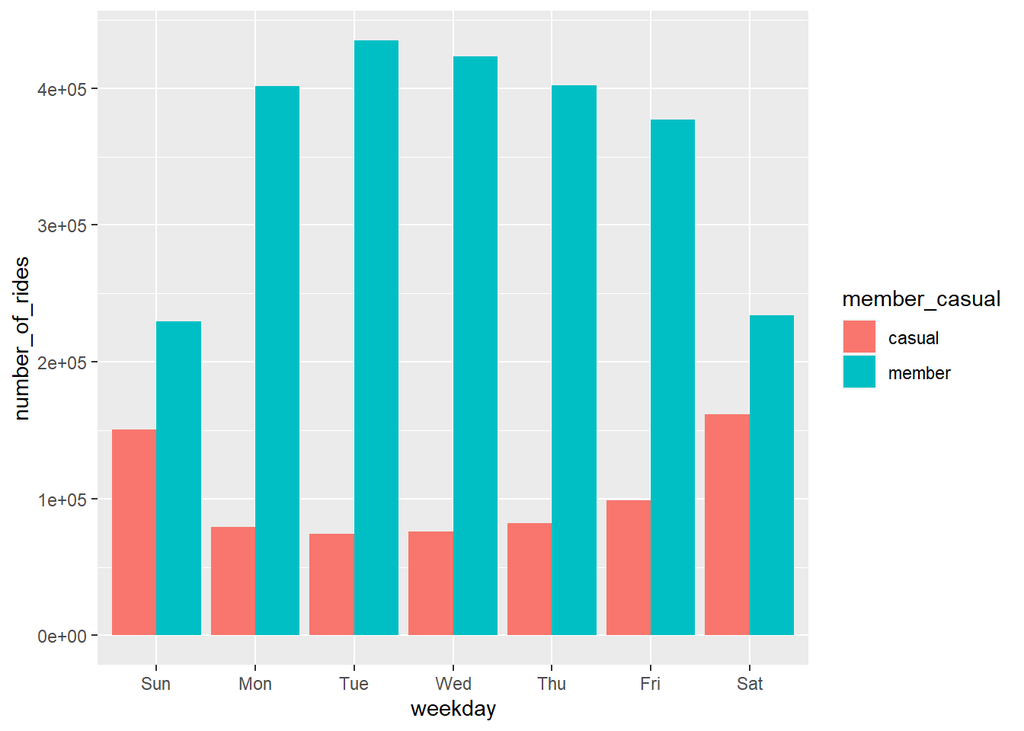

```r
all_trips_v2 %>%
  mutate(weekday = wday(started_at, label = TRUE)) %>%
  group_by(member_casual, weekday) %>%
  summarise(number_of_rides = n(), average_duration = mean(ride_length)) %>%
  arrange(member_casual, weekday)%>%
  ggplot(aes(x=weekday, y=number_of_rides, fill = member_casual)) + geom_col(position = 'dodge')
```

The visulaization clearly shows that the members have used the bikes more than casual riders. And it can also be seen that casual riders use the bikes more in weekends than weekdays.

Visualising the average duration (in seconds).

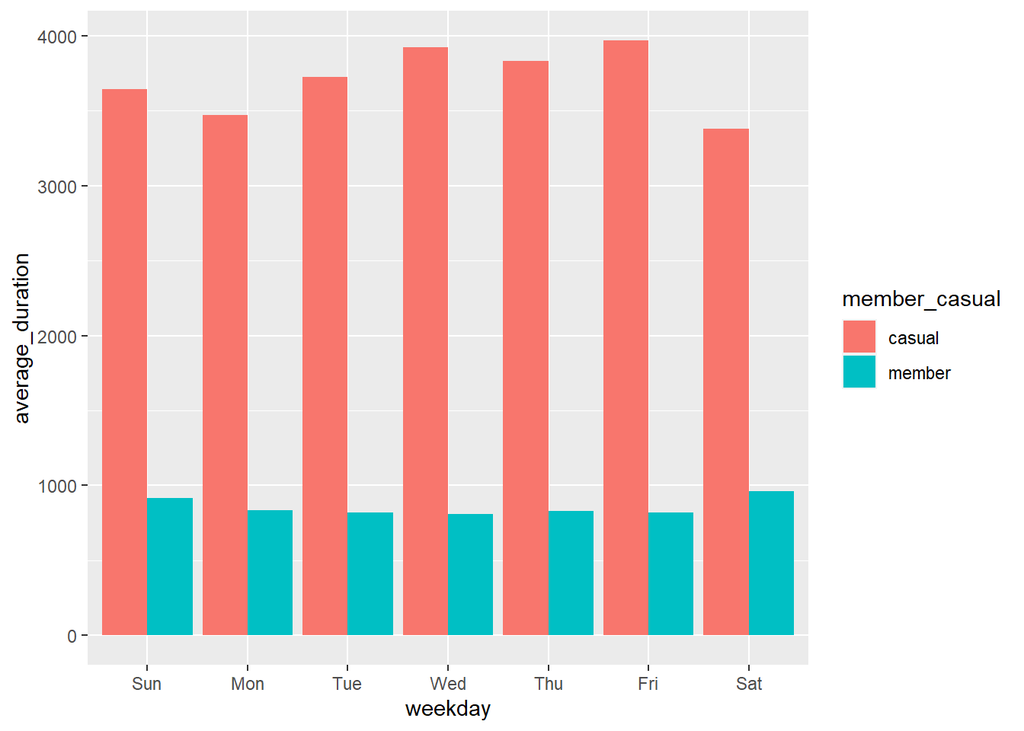

```r
all_trips_v2 %>%
  mutate(weekday = wday(started_at, label = TRUE)) %>%
  group_by(member_casual, weekday) %>%
  summarise(number_of_rides = n(),average_duration = mean(ride_length)) %>%
  arrange(member_casual, weekday) %>%
  ggplot(aes(x=weekday, y=average_duration, fill = member_casual)) + geom_col(position = "dodge")
```

This shows that the casual riders usually ride the bikes for longer period of time than members. This suggests that casual riders use the bikes to cover long distances and members use it for short distances.

*If additional data on the distance covered per trip was available, then it would have been helpful to understand how members use the bikes (work, school etc) and casual riders use them.*

Visualising the avergae duration (in seconds) of use between members and casual riders.

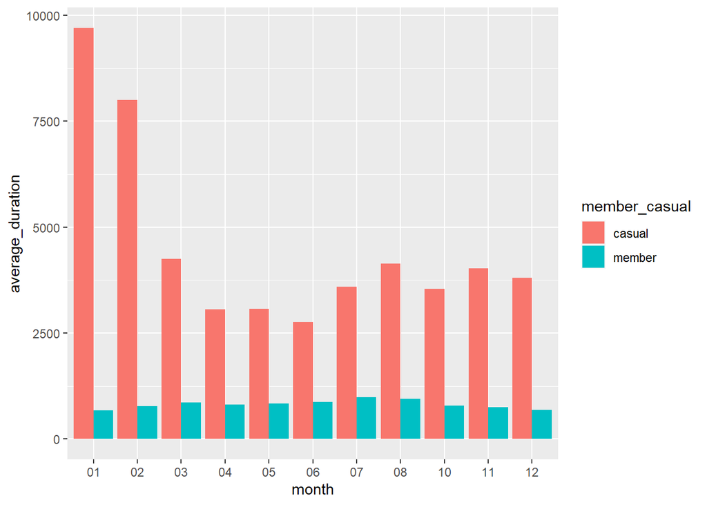

```r
all_trips_v2 %>%
  group_by(member_casual, month) %>%
  summarise(number_of_rides = n(),average_duration = mean(ride_length)) %>%
  arrange(member_casual, month) %>%
  ggplot(aes(x=month, y=average_duration, fill = member_casual)) + geom_col(position = "dodge")
```

Similar to average duration by weekday chart, casual riders use the bikes for a longer period of time.

Visualising the number of rides per month.

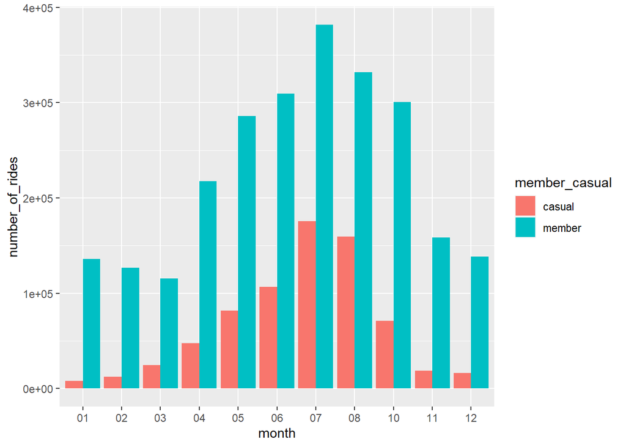

```r
all_trips_v2 %>%
  group_by(member_casual, month) %>%
  summarise(number_of_rides = n(), average_duration = mean(ride_length)) %>%
  arrange(member_casual, month)%>%
  ggplot(aes(x=month, y=number_of_rides, fill = member_casual)) + geom_col(position = 'dodge')
```

Members of Cyclistic have more number of rides than casual riders. * The starting of the months have less number of rides. * The months in the mid-year have high number of rides. * The number of rides are again reduced by the year end.

The reasons for above observations may be due to change in temperature or season. Additional data on average temperature in chicago can be helpful to understand it better.

## Summary of Analysis

- Members of Cyclistic have more number of rides than casual riders.
- casual riders use the bikes for a longer period of time.
- The rides are influenced by the season of the year.
- Further analysis can be done to understand the effectof temperature on the rides.
- The the duration of ride for members is similar throughout the year. This suggests that they are using the service for work.

## Recommendations

1. There are Casual riders who use the bikes for extremely long period of time. The reason should be further analysed. Since casual riders use the services for longer duration of time, the casual riders who are using the servies frequently can be targeted with ads and discounts to convert them into members.
2. Casual riders are using the services more in the weekends. Therefore, the prices of the passes (single, full-day) can be increased in the weekends and the prices of the annual membership should be made attractive so that casual riders might think of changing into annual members.
3. Further analysis can be done with some additional data on average temperature to understand the influence of temperature on number of rides.